# CMP330 Data Analytics - Assessment 2 (Pre-Assignment)

Md Jahirul Islam -> B00999362

# Objective

The task is to predict a car’s acceptability (`unacc`, `acc`, `good`, `vgood`) from six attributes describing the car. I’ll go through the usual EDA steps first, then compare five ML algorithms, and finally try to squeeze out some extra accuracy through feature selection and hyperparameter tuning.

# Part 1: Exploring and Preparing the Data

## 1.1 Reading the file in

The target and all predictors are categorical, so everything gets converted to a factor right after loading - otherwise R will treat some columns as plain character strings and a lot of the functions below won’t behave properly.

```r
eval_data <- read.csv("car.csv")
eval_data <- data.frame(lapply(eval_data, factor))

head(eval_data)
```

|  | buying | maint | doors | persons | lug_boot | safety | acceptability |
| --- | --- | --- | --- | --- | --- | --- | --- |
| 1 | vhigh | low | 5more | 4 | small | low | unacc |
| 2 | high | vhigh | 3 | 2 | med | low | unacc |
| 3 | vhigh | high | 4 | 4 | big | med | unacc |
| 4 | high | vhigh | 5more | 4 | med | low | unacc |
| 5 | vhigh | high | 5more | 2 | med | high | unacc |
| 6 | med | vhigh | 4 | more | small | med | unacc |

```r
str(eval_data)
```

```
'data.frame':   1000 obs. of  7 variables:
 $ buying       : Factor w/ 4 levels "high","low","med",..: 4 1 4 1 4 3 3 2 3 3 ...
 $ maint        : Factor w/ 4 levels "high","low","med",..: 2 4 1 4 1 4 3 4 2 2 ...
 $ doors        : Factor w/ 4 levels "2","3","4","5more": 4 2 3 4 4 3 3 1 3 3 ...
 $ persons      : Factor w/ 3 levels "2","4","more": 2 1 2 2 1 3 1 3 2 3 ...
 $ lug_boot     : Factor w/ 3 levels "big","med","small": 3 2 1 2 2 3 1 1 3 1 ...
 $ safety       : Factor w/ 3 levels "high","low","med": 2 2 3 2 1 3 3 1 3 3 ...
 $ acceptability: Factor w/ 4 levels "acc","good","unacc",..: 3 3 3 3 3 3 3 1 1 2 ...
```

## 1.2 Basic counts

Just wanted to get a feel for the data before doing anything fancy - how balanced are the classes, and does anything jump out from a couple of cross-tabs.

```r
# class balance - turns out "unacc" dominates, which makes sense since most
# combinations of features probably don't produce a "great" car
table(eval_data$acceptability)
```

```
  acc  good unacc vgood
  231    41   693    35
```

```r
table(eval_data$buying, eval_data$acceptability)
```

```
        acc good unacc vgood
  high   72    0   198     0
  low    51   27   138    22
  med    68   14   162    13
  vhigh  40    0   195     0
```

```r
# curious whether low-safety cars are basically never rated highly
table(eval_data$safety, eval_data$acceptability)
```

```
       acc good unacc vgood
  high 131   19   145    35
  low    0    0   337     0
  med  100   22   211     0
```

```r
# and whether 2-seaters get penalised regardless of everything else
table(eval_data$persons, eval_data$acceptability)
```

```
       acc good unacc vgood
  2      0    0   321     0
  4    116   20   188    19
  more 115   21   184    16
```

## 1.3 Some plots

I went with a few different chart types here instead of just bar charts, to get a couple of different angles on the same data.

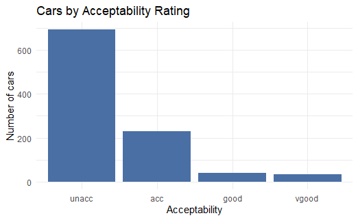

```r
library(ggplot2)

eval_data$acceptability <- factor(eval_data$acceptability,
                                   levels = c("unacc", "acc", "good", "vgood"))

# plain bar chart of the target - good starting point
ggplot(eval_data, aes(x = acceptability)) +
  geom_bar(fill = "#4A6FA5") +
  labs(title = "Cars by Acceptability Rating", x = "Acceptability", y = "Number of cars") +
  theme_minimal()
```

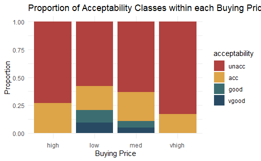

```r
# stacked proportion chart instead of dodge, to see the *relative* mix of
# classes within each buying price band rather than raw counts
ggplot(eval_data, aes(x = buying, fill = acceptability)) +
  geom_bar(position = "fill") +
  scale_fill_manual(values = c("#B0413E", "#DDA448", "#3C6E71", "#284B63")) +
  labs(title = "Proportion of Acceptability Classes within each Buying Price",
       x = "Buying Price", y = "Proportion") +
  theme_minimal()
```

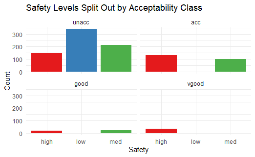

```r
# faceted view - safety broken out into its own small panels, one per class
ggplot(eval_data, aes(x = safety, fill = safety)) +
  geom_bar() +
  facet_wrap(~ acceptability) +
  scale_fill_brewer(palette = "Set1") +
  labs(title = "Safety Levels Split Out by Acceptability Class", x = "Safety", y = "Count") +
  theme_minimal() +
  theme(legend.position = "none")
```